# Istatistiksel Yazilimlar II Final Sinavi (18.06.2019, saat: 11:00-13:00)

Vizenizi 18 Haziran 11:00 e kadar asagidaki linke yukleyiniz.

https://www.dropbox.com/request/kBa5A2sNxb5BFnwMEiyu

Gerekli kutuphaneleri yukleyiniz.

```r
library(ISLR)
library(formatR)
```

```r
library(ggplot2)
library(corrplot)
library(boot)
library(readr)
library(summarytools)
```

## 1. VERININ TANIMLANMASI VE OZETLENMESI

### i. Veri setinizin kaynagini belirtiniz. Bagimli ve aciklayici degiskenleri tanimlayiniz. (5 p)

- kaynak: https://www.kaggle.com/kandij/diabetes-dataset
- aciklama: Veriler, Pima Yerlileri Diyabet Veritabaninin bir parcasi olarak “Ulusal Diyabet ve Sindirim ve Böbrek Hastaliklari Enstitusu” tarafindan toplandi ve kullanima sunuldu. buradaki tüm hastalar Pima Indian mirasina (Amerikan Yerlilerinin alt grubu) aittir ve 21 yas ve ustu kadinlardir.
1. Bagimli degisken: sonuc: hastanin diyabet olup olmadigi
2. aciklayici degisken 1:gebelik: hasta kac gebelik gecirmis
3. aciklayici degisken 2:glikoz: vucuttaki glikoz degeri
4. aciklayici degisken 3:kanbasinci: kanbasinci degeri
5. aciklayici degisken 4:ciltkalinligi: cildin kalinligi
6. aciklayici degisken 5:ensulin: ensulin degeri
7. aciklayici degisken 6:bmi: vucut kitle indeksi
8. aciklayici degisken 7:diyabetsoyagaci
9. aciklayici degisken 8:yas
- gozlem sayisi: 768
- aciklayici degisken sayisi:8

```r
#Kodunuzu buraya giriniz
library(readr)
diabetes2 <- read_csv("C:\\Users\\PC\\Desktop\\diabetes2.csv")
View(diabetes2)
```

```r
library(caret)
set.seed(123)
test <- createDataPartition(diabetes2$sonuc, p = .2,list = FALSE)
data_train <- diabetes2[ -test, ]
data_test  <- diabetes2[ test, ]
```

verimizi test ve train olarak ikiye ayirdik. burada verilerin %80’i train kalan %20’si test olarak ayrilmistir.

### ii. Veri setinizde kategorik ve sayisal degiskenleri uygun bicimde tanimlayarak, (as.factor(), as.numeric() …)) hem kategorik hem sayisal degiskenlerin ozet istatistiklerini elde ediniz. (5 p)

```r
#Kodunuzu buraya giriniz
descr(diabetes2)
```

```
## Descriptive Statistics
## diabetes2
## N: 768
##
##                        bmi   ciltkalinligi   diyabetsoyagaci   ensulin   gebelik   glikoz
## ----------------- -------- --------------- ----------------- --------- --------- --------
##              Mean    31.99           20.54              0.47     79.80      3.85   120.89
##           Std.Dev     7.88           15.95              0.33    115.24      3.37    31.97
##               Min     0.00            0.00              0.08      0.00      0.00     0.00
##                Q1    27.30            0.00              0.24      0.00      1.00    99.00
##            Median    32.00           23.00              0.37     30.50      3.00   117.00
##                Q3    36.60           32.00              0.63    127.50      6.00   140.50
##               Max    67.10           99.00              2.42    846.00     17.00   199.00
##               MAD     6.82           17.79              0.25     45.22      2.97    29.65
##               IQR     9.30           32.00              0.38    127.25      5.00    41.25
##                CV     0.25            0.78              0.70      1.44      0.88     0.26
##          Skewness    -0.43            0.11              1.91      2.26      0.90     0.17
##       SE.Skewness     0.09            0.09              0.09      0.09      0.09     0.09
##          Kurtosis     3.24           -0.53              5.53      7.13      0.14     0.62
##           N.Valid   768.00          768.00            768.00    768.00    768.00   768.00
##         Pct.Valid   100.00          100.00            100.00    100.00    100.00   100.00
##
## Table: Table continues below
##
##
##
##                     kanbasinci    sonuc      yas
## ----------------- ------------ -------- --------
##              Mean        69.11     0.35    33.24
##           Std.Dev        19.36     0.48    11.76
##               Min         0.00     0.00    21.00
##                Q1        62.00     0.00    24.00
##            Median        72.00     0.00    29.00
##                Q3        80.00     1.00    41.00
##               Max       122.00     1.00    81.00
##               MAD        11.86     0.00    10.38
##               IQR        18.00     1.00    17.00
##                CV         0.28     1.37     0.35
##          Skewness        -1.84     0.63     1.13
##       SE.Skewness         0.09     0.09     0.09
##          Kurtosis         5.12    -1.60     0.62
##           N.Valid       768.00   768.00   768.00
##         Pct.Valid       100.00   100.00   100.00
```

```r
freq(diabetes2)
```

```
## Variable(s) ignored: glikoz, kanbasinci, ciltkalinligi, ensulin, bmi, diyabetsoyagaci, yas
```

```
## Frequencies
## diabetes2$gebelik
## Type: Numeric
##
##               Freq   % Valid   % Valid Cum.   % Total   % Total Cum.
## ----------- ------ --------- -------------- --------- --------------
##           0    111     14.45          14.45     14.45          14.45
##           1    135     17.58          32.03     17.58          32.03
##           2    103     13.41          45.44     13.41          45.44
##           3     75      9.77          55.21      9.77          55.21
##           4     68      8.85          64.06      8.85          64.06
##           5     57      7.42          71.48      7.42          71.48
##           6     50      6.51          77.99      6.51          77.99
##           7     45      5.86          83.85      5.86          83.85
##           8     38      4.95          88.80      4.95          88.80
##           9     28      3.65          92.45      3.65          92.45
##          10     24      3.12          95.57      3.12          95.57
##          11     11      1.43          97.01      1.43          97.01
##          12      9      1.17          98.18      1.17          98.18
##          13     10      1.30          99.48      1.30          99.48
##          14      2      0.26          99.74      0.26          99.74
##          15      1      0.13          99.87      0.13          99.87
##          17      1      0.13         100.00      0.13         100.00
##        <NA>      0                               0.00         100.00
##       Total    768    100.00         100.00    100.00         100.00
##
## diabetes2$sonuc
## Type: Numeric
##
##               Freq   % Valid   % Valid Cum.   % Total   % Total Cum.
## ----------- ------ --------- -------------- --------- --------------
##           0    500     65.10          65.10     65.10          65.10
##           1    268     34.90         100.00     34.90         100.00
##        <NA>      0                               0.00         100.00
##       Total    768    100.00         100.00    100.00         100.00
```

burada verimizin ozetini cikartiyoruz.

### iii. Bagimli degiskeninizi gorsellestiriniz(bar chart vs.). Bagimli degiskenin her bir sinifindaki gozlem sayisina baktiginizda, dengeli(balanced/imbalanced) dagilmis midir? (5 p)

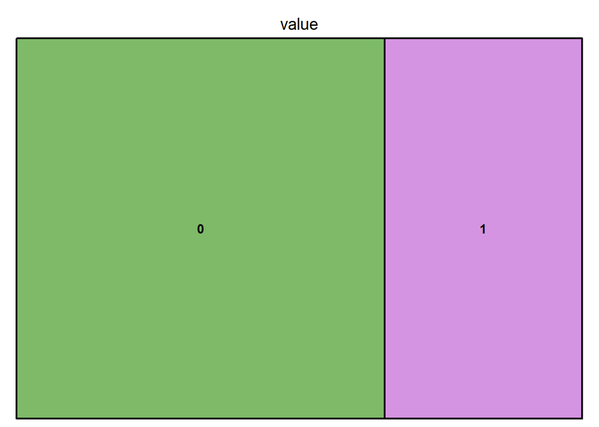

```r
library(treemap)
# Create data
group=c("0","1")
value=c(500,268)
data=data.frame(group,value)
# treemap
treemap(data,
        index="group",
        vSize="value",
        type="index")
```

bagimli degiskenimiz olan sonuc degerlerinin treemap’inin cizdik.imbalance veri oldugunu soyleyebiliriz. çünkü 0’lar yani diyabet olmayanlar daha fazla.

```r
library(ggplot2)

# The iris dataset is proposed by R
head(diabetes2)
```

```
## # A tibble: 6 x 9
##   gebelik glikoz kanbasinci ciltkalinligi ensulin   bmi diyabetsoyagaci
##     <dbl>  <dbl>      <dbl>         <dbl>   <dbl> <dbl>           <dbl>
## 1       6    148         72            35       0  33.6           0.627
## 2       1     85         66            29       0  26.6           0.351
## 3       8    183         64             0       0  23.3           0.672
## 4       1     89         66            23      94  28.1           0.167
## 5       0    137         40            35     168  43.1           2.29
## 6       5    116         74             0       0  25.6           0.201
## # ... with 2 more variables: yas <dbl>, sonuc <dbl>
```

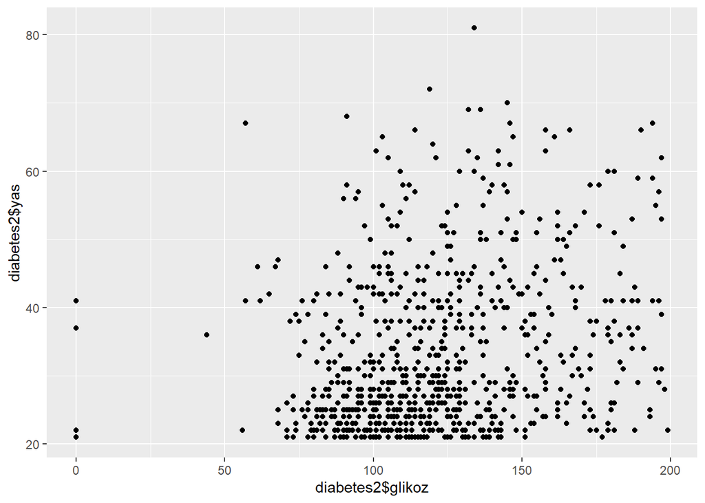

```r
# basic scatterplot
ggplot(diabetes2, aes(x=diabetes2$glikoz, y=diabetes2$yas)) +
    geom_point()
```

sacininm grafigine bakarsak glikozun yasa gore degismedigini soyleyebiliriz. glikoz degerinin genel olarak 75 ve 150 arasinda yogun olarak goruldugu soylenebilir.

### iv. Veri setinizdeki aciklayici degiskenler icin uygun gorsellestirmeleri yapiniz. Aciklayici degiskenlerin bagimli degisken ile iliskilerini ortaya cikaracak gorseller olmasina dikkat ediniz (10 p).

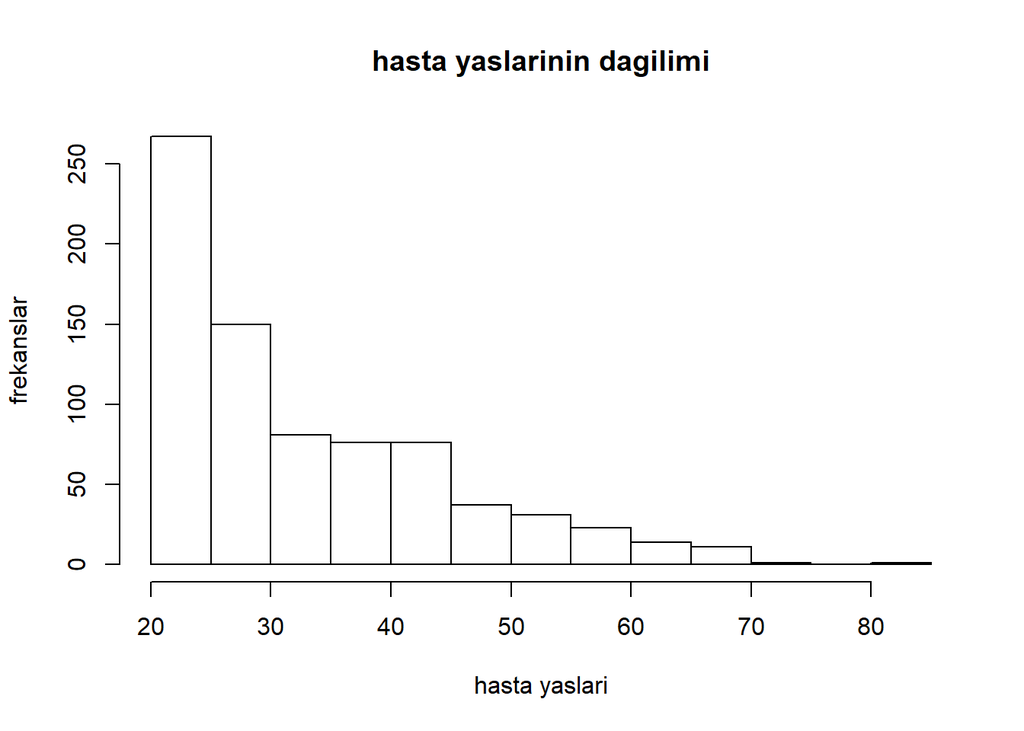

```r
hist(diabetes2$yas,xlab="hasta yaslari",ylab="frekanslar",main="hasta yaslarinin dagilimi")
```

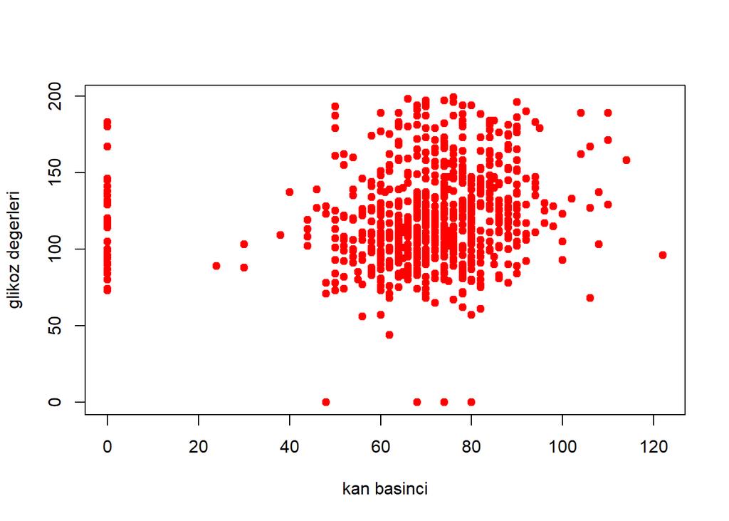

```r
plot(diabetes2$kanbasinci,diabetes2$glikoz,col=c("red"),pch=19,xlab="kan basinci",ylab="glikoz degerleri")
```

hist; incelenen hastalarin yaslarinin 20 ve 45 arasinda fazlalik gosterdigini soyleyebiliriz. yas arttikca hasta sayisi azalmaktadir.

sacinim; kan basincinin 40 ve 100 arasinda oldugu durumda en yuksek glikoz degerine sahiptir diyebiliriz.

```r
library(ggplot2)
head(diabetes2)
```

```
## # A tibble: 6 x 9
##   gebelik glikoz kanbasinci ciltkalinligi ensulin   bmi diyabetsoyagaci
##     <dbl>  <dbl>      <dbl>         <dbl>   <dbl> <dbl>           <dbl>
## 1       6    148         72            35       0  33.6           0.627
## 2       1     85         66            29       0  26.6           0.351
## 3       8    183         64             0       0  23.3           0.672
## 4       1     89         66            23      94  28.1           0.167
## 5       0    137         40            35     168  43.1           2.29
## 6       5    116         74             0       0  25.6           0.201
## # ... with 2 more variables: yas <dbl>, sonuc <dbl>
```

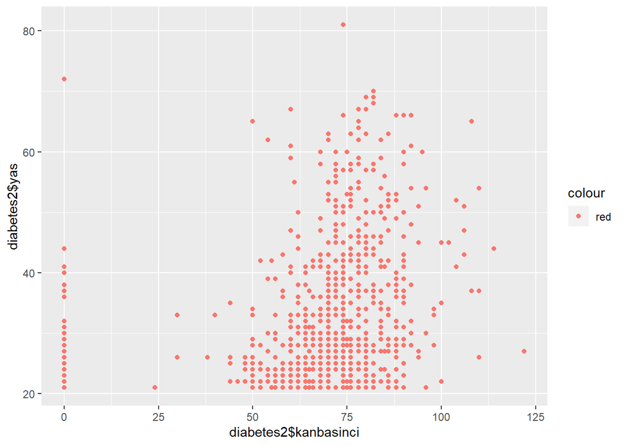

```r
ggplot(diabetes2, aes(x=diabetes2$kanbasinci, y=diabetes2$yas, col="red")) +
    geom_point()
```

kan basincinin yasa gore degistigini soyleyemeyiz. ancak 50 ve 80 arasinda yogunluk oldugunu soyleyebiliriz.

### v. Aciklayici degiskenler arasi korelasyonlari hesaplayiniz (sadece sayisal degerler yerine corrplot,ggpairs vs. gibi hem sayi hem gorsellik iceren korelasyon tablolari elde ediniz)(5 p).

```r
library(GGally)
```

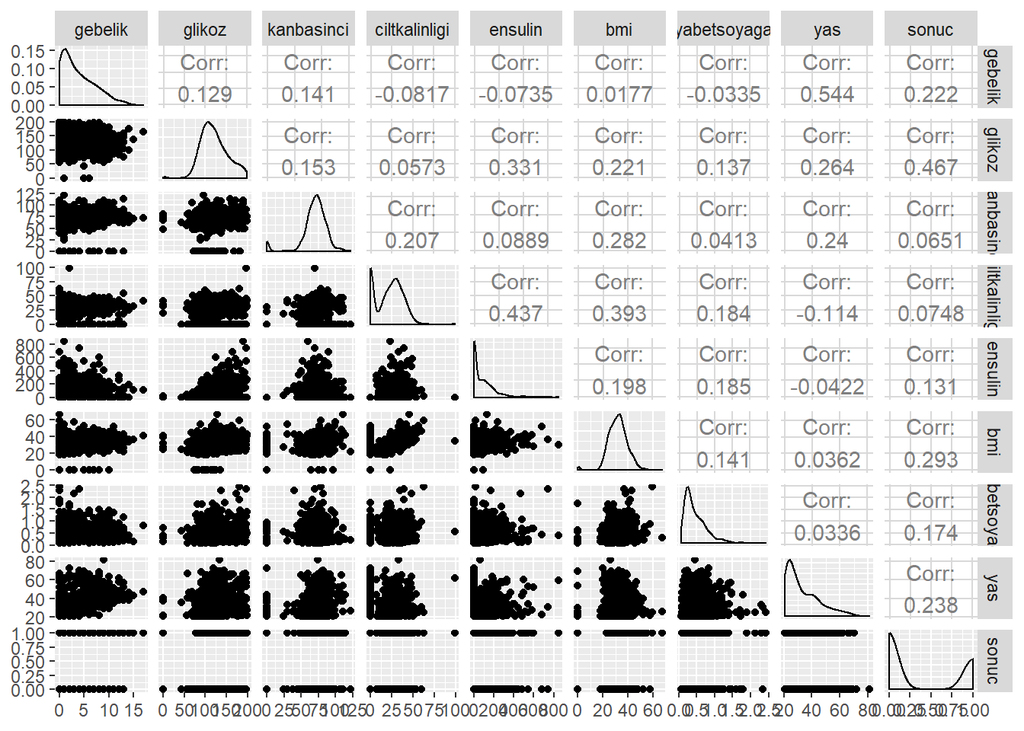

```r
ggpairs(diabetes2)
```

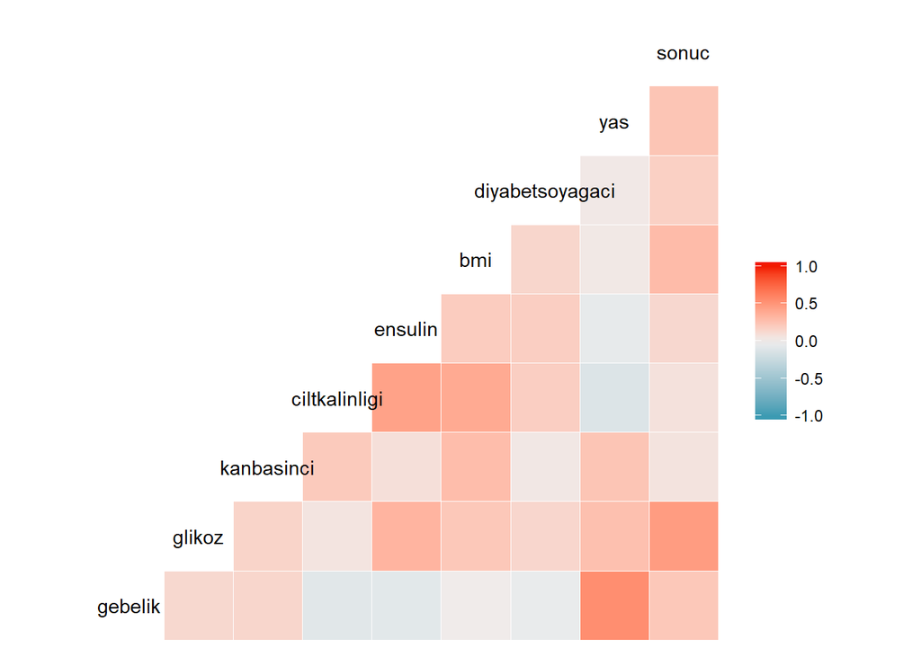

```r
ggcorr(diabetes2)
```

ilk grafikte butun degiskenlerin birbirleiyle olan korelasyonlarini, sacinim ve alan grafiklerinin goruyoruz. ikinci grafikte maviden kirmiziya gidildikce iliskinin arttigini soyleyebiliriz. ornegin burada gebelik ve yas araisnda yÃ¼ksek korelasyon vardir diyebiliriz.

## 2. LOJISTIK REGRESYON MODELININ KURULMASI

### i. Lojistik regresyon modelini kurunuz (kategorik degiskenlerin modele kategorik olarak girdigine emin olunuz). Sonuclarin ozetini, odds oranlarini (guven aralikalri ile) ve ilgili anova tablosunu elde ediniz (glm(),summary(), anova()). (5 p)

```r
#model
library(fmsb)
model.lojistik=glm(sonuc~glikoz+yas+kanbasinci+bmi+ensulin+diyabetsoyagaci+gebelik+ciltkalinligi,family="binomial",data=diabetes2)
summary(model.lojistik)
```

```
##
## Call:
## glm(formula = sonuc ~ glikoz + yas + kanbasinci + bmi + ensulin +
##     diyabetsoyagaci + gebelik + ciltkalinligi, family = "binomial",
##     data = diabetes2)
##
## Deviance Residuals:
##     Min       1Q   Median       3Q      Max
## -2.5566  -0.7274  -0.4159   0.7267   2.9297
##
## Coefficients:
##                   Estimate Std. Error z value Pr(>|z|)
## (Intercept)     -8.4046964  0.7166359 -11.728  < 2e-16 ***
## glikoz           0.0351637  0.0037087   9.481  < 2e-16 ***
## yas              0.0148690  0.0093348   1.593 0.111192
## kanbasinci      -0.0132955  0.0052336  -2.540 0.011072 *
## bmi              0.0897010  0.0150876   5.945 2.76e-09 ***
## ensulin         -0.0011917  0.0009012  -1.322 0.186065
## diyabetsoyagaci  0.9451797  0.2991475   3.160 0.001580 **
## gebelik          0.1231823  0.0320776   3.840 0.000123 ***
## ciltkalinligi    0.0006190  0.0068994   0.090 0.928515
## ---
## Signif. codes:  0 '***' 0.001 '**' 0.01 '*' 0.05 '.' 0.1 ' ' 1
##
## (Dispersion parameter for binomial family taken to be 1)
##
##     Null deviance: 993.48  on 767  degrees of freedom
## Residual deviance: 723.45  on 759  degrees of freedom
## AIC: 741.45
##
## Number of Fisher Scoring iterations: 5
```

```r
anova(model.lojistik)
```

```
## Analysis of Deviance Table
##
## Model: binomial, link: logit
##
## Response: sonuc
##
## Terms added sequentially (first to last)
##
##
##                 Df Deviance Resid. Df Resid. Dev
## NULL                              767     993.48
## glikoz           1  184.764       766     808.72
## yas              1   11.358       765     797.36
## kanbasinci       1    1.072       764     796.29
## bmi              1   46.701       763     749.59
## ensulin          1    1.418       762     748.17
## diyabetsoyagaci  1    9.478       761     738.69
## gebelik          1   15.239       760     723.45
## ciltkalinligi    1    0.008       759     723.45
```

```r
glm(model.lojistik)
```

```
##
## Call:  glm(formula = model.lojistik)
##
## Coefficients:
##     (Intercept)           glikoz              yas       kanbasinci
##      -0.8538943        0.0059203        0.0026214       -0.0023319
##             bmi          ensulin  diyabetsoyagaci          gebelik
##       0.0132440       -0.0001805        0.1472374        0.0205919
##   ciltkalinligi
##       0.0001545
##
## Degrees of Freedom: 767 Total (i.e. Null);  759 Residual
## Null Deviance:       174.5
## Residual Deviance: 121.6     AIC: 783.8
```

```r
#odds oranlari
exp(cbind(OR = coef(model.lojistik), confint(model.lojistik)))
```

```
##                           OR        2.5 %       97.5 %
## (Intercept)     0.0002238137 5.220567e-05 0.0008690532
## glikoz          1.0357892688 1.028491e+00 1.0435726573
## yas             1.0149800983 9.965029e-01 1.0337433880
## kanbasinci      0.9867924485 9.765958e-01 0.9969008370
## bmi             1.0938471417 1.062739e+00 1.1275654616
## ensulin         0.9988090108 9.970375e-01 1.0005823121
## diyabetsoyagaci 2.5732758592 1.441047e+00 4.6583260840
## gebelik         1.1310905981 1.062812e+00 1.2054534756
## ciltkalinligi   1.0006191560 9.872327e-01 1.0143130404
```

### ii. Aciklayici degiskenler ile bagimli degisken arasinda iliski var midir? Model ciktilarini yorumlayiniz (Odds ratio vs.). (5 p)

ensulin, yas ve cilt kalinliginin sonuc(diyabet olup olmama) ile bir iliskisi olmadigini soyleyebiliriz. odds degerlerine bakarsak; glikoz’un, bmi’nin,yas’in, cilt kalinligi’nin, diyabetsoyagaci’nin ve gebeligin sonuc(diyabet olup olmama) uzerinde arttirici bir etkisi vardir. kanbasinci ve ensulinin ise sonuc uzerinde azaltici etkisi vardir. ayrica ilk modelin AIC degeri daha kucuk oldugu icin en uygun modelin ilki oldugunu soyleriz.

### iv. Siniflandirma yapmak icin optimum kesim noktasini bulunuz.(5 p)

```r
olasilik=predict(model.lojistik,diabetes2,"response")
#esik degerini 0.5 alarak sinif tahminlerini yapiniz
diabetes2$diabetes_test=ifelse(olasilik>0.5,"yes","no")
diabetes2$diabetes_test=as.factor(diabetes2$diabetes_test)
table.lojistik=table(Tahmin=diabetes2$diabetes_test, Referans=diabetes2$sonuc)
accu.lojistik=(table.lojistik[1,1]+table.lojistik[2,2])/768
accu.lojistik
```

```
## [1] 0.7825521
```

```r
library(rpart)
fit1=rpart(sonuc ~ glikoz+yas+kanbasinci+bmi+ensulin+diyabetsoyagaci+gebelik+ciltkalinligi,
          data = diabetes2) #gini index
summary(fit1)
```

```
## Call:
## rpart(formula = sonuc ~ glikoz + yas + kanbasinci + bmi + ensulin +
##     diyabetsoyagaci + gebelik + ciltkalinligi, data = diabetes2)
##   n= 768
##
##            CP nsplit rel error    xerror       xstd
## 1  0.18156927      0 1.0000000 1.0026286 0.02294019
## 2  0.05325717      1 0.8184307 0.8574763 0.03408005
## 3  0.04177890      2 0.7651736 0.8165068 0.03579551
## 4  0.02327910      3 0.7233947 0.7599032 0.03456309
## 5  0.02176736      4 0.7001156 0.7712774 0.03604698
## 6  0.01993511      5 0.6783482 0.7689580 0.03712476
## 7  0.01605040      6 0.6584131 0.7606933 0.03790023
## 8  0.01515515      8 0.6263123 0.7441984 0.03796129
## 9  0.01465071      9 0.6111571 0.7422364 0.03805477
## 10 0.01002676     10 0.5965064 0.7450379 0.03947502
## 11 0.01000000     11 0.5864797 0.7510557 0.04086384
##
## Variable importance
##          glikoz             bmi             yas      kanbasinci
##              41              18              13               8
##         ensulin         gebelik diyabetsoyagaci   ciltkalinligi
##               8               5               4               2
##
## Node number 1: 768 observations,    complexity param=0.1815693
##   mean=0.3489583, MSE=0.2271864
##   left son=2 (485 obs) right son=3 (283 obs)
##   Primary splits:
##       glikoz  < 127.5  to the left,  improve=0.18156930, (0 missing)
##       yas     < 28.5   to the left,  improve=0.09740653, (0 missing)
##       bmi     < 29.85  to the left,  improve=0.09435089, (0 missing)
##       gebelik < 6.5    to the left,  improve=0.05643353, (0 missing)
##       ensulin < 121    to the left,  improve=0.03822594, (0 missing)
##   Surrogate splits:
##       ensulin         < 121    to the left,  agree=0.697, adj=0.177, (0 split)
##       yas             < 48.5   to the left,  agree=0.665, adj=0.092, (0 split)
##       kanbasinci      < 81     to the left,  agree=0.659, adj=0.074, (0 split)
##       bmi             < 39.75  to the left,  agree=0.659, adj=0.074, (0 split)
##       diyabetsoyagaci < 1.149  to the left,  agree=0.642, adj=0.028, (0 split)
##
```

[output cut: 161 more lines]

```
##
## Node number 29: 65 observations
##   mean=0.7230769, MSE=0.2002367
##
## Node number 46: 84 observations
##   mean=0.4047619, MSE=0.2409297
##
## Node number 47: 34 observations
##   mean=0.7352941, MSE=0.1946367
##
## Node number 56: 40 observations
##   mean=0.325, MSE=0.219375
##
## Node number 57: 10 observations
##   mean=1, MSE=0
```

```r
fit1
```

```
## n= 768
##
## node), split, n, deviance, yval
##       * denotes terminal node
##
##  1) root 768 174.479200 0.34895830
##    2) glikoz< 127.5 485  75.781440 0.19381440
##      4) yas< 28.5 271  21.047970 0.08487085
##        8) bmi< 30.95 151   1.973510 0.01324503 *
##        9) bmi>=30.95 120  17.325000 0.17500000 *
##      5) yas>=28.5 214  47.443930 0.33177570
##       10) bmi< 26.35 41   1.902439 0.04878049 *
##       11) bmi>=26.35 173  41.479770 0.39884390
##         22) glikoz< 99.5 55   8.181818 0.18181820 *
##         23) glikoz>=99.5 118  29.500000 0.50000000
##           46) diyabetsoyagaci< 0.561 84  20.238100 0.40476190 *
##           47) diyabetsoyagaci>=0.561 34   6.617647 0.73529410 *
##    3) glikoz>=127.5 283  67.017670 0.61484100
##      6) bmi< 29.95 76  16.421050 0.31578950
##       12) glikoz< 145.5 41   5.121951 0.14634150 *
##       13) glikoz>=145.5 35   8.742857 0.51428570 *
##      7) bmi>=29.95 207  41.304350 0.72463770
##       14) glikoz< 157.5 115  27.391300 0.60869570
##         28) yas< 30.5 50  12.420000 0.46000000
##           56) kanbasinci>=61 40   8.775000 0.32500000 *
##           57) kanbasinci< 61 10   0.000000 1.00000000 *
##         29) yas>=30.5 65  13.015380 0.72307690 *
##       15) glikoz>=157.5 92  10.434780 0.86956520 *
```

```r
#karar agaci 2
fit2=rpart(sonuc~glikoz+yas+kanbasinci+bmi+ensulin+diyabetsoyagaci+gebelik+ciltkalinligi,
           data = diabetes2) #entropy
summary(fit2)
```

```
## Call:
## rpart(formula = sonuc ~ glikoz + yas + kanbasinci + bmi + ensulin +
##     diyabetsoyagaci + gebelik + ciltkalinligi, data = diabetes2)
##   n= 768
##
##            CP nsplit rel error    xerror       xstd
## 1  0.18156927      0 1.0000000 1.0016231 0.02291386
## 2  0.05325717      1 0.8184307 0.8586846 0.03410340
## 3  0.04177890      2 0.7651736 0.8205511 0.03706184
## 4  0.02327910      3 0.7233947 0.7760146 0.03448024
## 5  0.02176736      4 0.7001156 0.7855035 0.03570068
## 6  0.01993511      5 0.6783482 0.7620815 0.03592628
## 7  0.01605040      6 0.6584131 0.7554920 0.03659525
## 8  0.01515515      8 0.6263123 0.7476597 0.03705387
## 9  0.01465071      9 0.6111571 0.7487667 0.03712264
## 10 0.01002676     10 0.5965064 0.7382598 0.03871907
## 11 0.01000000     11 0.5864797 0.7673941 0.04068952
##
## Variable importance
##          glikoz             bmi             yas      kanbasinci
##              41              18              13               8
##         ensulin         gebelik diyabetsoyagaci   ciltkalinligi
##               8               5               4               2
##
## Node number 1: 768 observations,    complexity param=0.1815693
##   mean=0.3489583, MSE=0.2271864
##   left son=2 (485 obs) right son=3 (283 obs)
##   Primary splits:
##       glikoz  < 127.5  to the left,  improve=0.18156930, (0 missing)
##       yas     < 28.5   to the left,  improve=0.09740653, (0 missing)
##       bmi     < 29.85  to the left,  improve=0.09435089, (0 missing)
##       gebelik < 6.5    to the left,  improve=0.05643353, (0 missing)
##       ensulin < 121    to the left,  improve=0.03822594, (0 missing)
##   Surrogate splits:
##       ensulin         < 121    to the left,  agree=0.697, adj=0.177, (0 split)
##       yas             < 48.5   to the left,  agree=0.665, adj=0.092, (0 split)
##       kanbasinci      < 81     to the left,  agree=0.659, adj=0.074, (0 split)
##       bmi             < 39.75  to the left,  agree=0.659, adj=0.074, (0 split)
##       diyabetsoyagaci < 1.149  to the left,  agree=0.642, adj=0.028, (0 split)
##
```

[output cut: 161 more lines]

```
##
## Node number 29: 65 observations
##   mean=0.7230769, MSE=0.2002367
##
## Node number 46: 84 observations
##   mean=0.4047619, MSE=0.2409297
##
## Node number 47: 34 observations
##   mean=0.7352941, MSE=0.1946367
##
## Node number 56: 40 observations
##   mean=0.325, MSE=0.219375
##
## Node number 57: 10 observations
##   mean=1, MSE=0
```

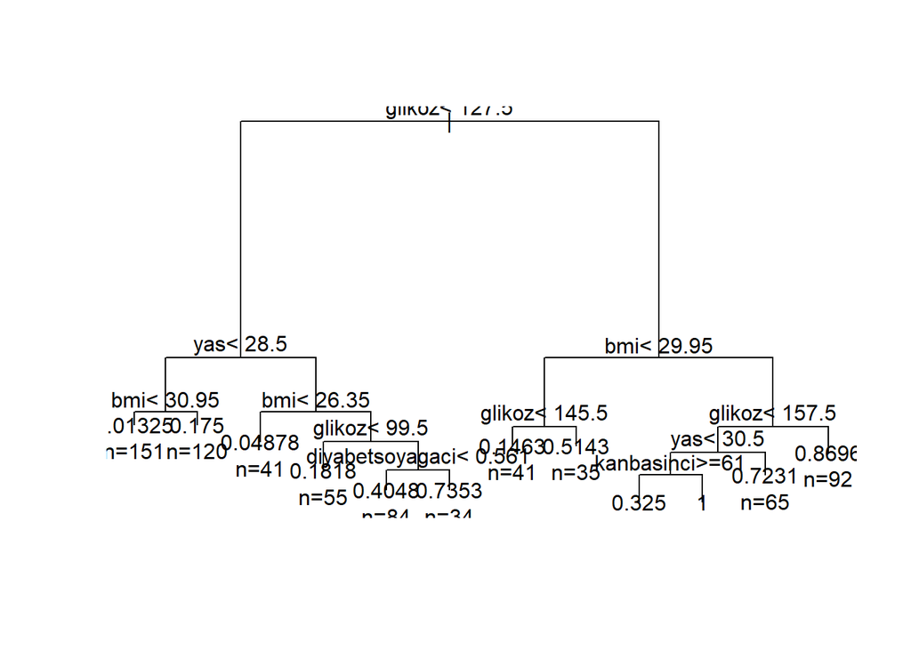

```r
plot(fit1)
text(fit1, use.n = TRUE)
```

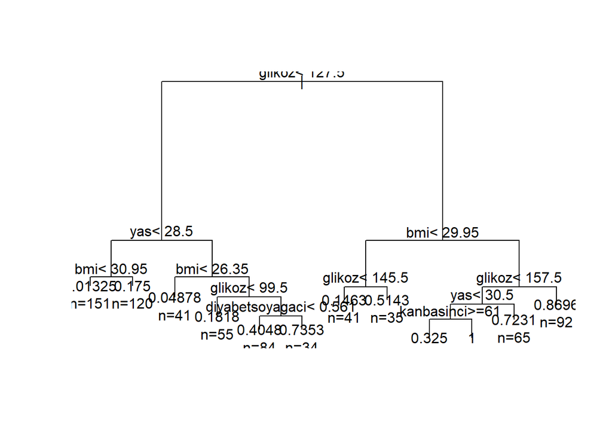

```r
plot(fit2)
text(fit2, use.n = TRUE)
```